# LakeN

Yoav Ben Dor

6.12.2016

# Introduction

This model was written as a project for course 68806 Eco-hydrologic modelling with R This model illustrates the annual N cycle in a lake in northern Israel, and simulates the transitions from oxydized species into reduced species

## Background

Anthropogenic effects of the recent years has largely affected the nitrogen cycle during the last decades. Increased N inputs, primarily as river-born nitrate, originating in soils, encourage eutrophication, anoxic conditions and blooms of harmful algae, interrupting the ecological cycle. The nitrogen cycle includes several key processes, which include its cycling between several species and affect its bioavailability. Rivers are efficient N sinks, but in its inorganic forms, it is removed from the water through assimilation and adsorption onto sediments. In addition, the precipitation of organic N and denitrification are two major processes that remove N from the water. In the studied lake, an N-fixing algae of the cyanobacteria phylum appeared for the first time during the autumn of 1994. It reappears every year since that time, and was recently accompanied by another cyanobacteria specie since 2005. This dramatic change in lake ecology is the likely result of changes in the availability of water-soluble nutrients, which provided the N-fixing species with a relative ecological advantage.

## N cycle in the studied lake

Several key process dominate the N cycle of the studied lake. These include nitrification, denitrification and the fixing of atmospheric nitrogen. These three processes are biologically mediated, and their relative role in the transformation of one specie to another greatly depends on physical conditions including radiation and temperature as well as the chemical properties of the lake, which are largely dependent on its limnological cycle. The consideration of these parameters in a limnological perspective is essential for the consideration of the dominant processes and their ecological impact. These processes are briefly described in the section below:

### Nitrification

Nitrification includes the oxidation of ammonia into nitrite in a two-stage process mediated by the nitrosomonas bacteria followed by the oxidation of nitrate through the mediation of the nitrobacteria, that can be summarized as:
$$NH_4^+ →NH_3→NO_2^-→NO_3$$

This process largely depends on oxygen availability, ambient conditions and the size of bacterial populations. The process has been documented to be carried quickly into nitrate in some years, whereas in others the increase in nitrite preceded the transformation into nitrate by several days up to a couple of weeks.

# Data preparation

The data is provided in discrete form of concentration measurments. The depths of the measurments are not constant, and the time intervals between measurments are also not constant, and range from several days to several weeks.

### read the data and load relevant libraries

## Interpolate the Data into 1 m Intervals

Use the function “depthinterp”" to interpolate the data into uniform length for every 1 m. This is essential for later calculating the volume of each depth interval and the mass of each N specie measured in this depth.

### Demonstrate interpolations of randomly selected data

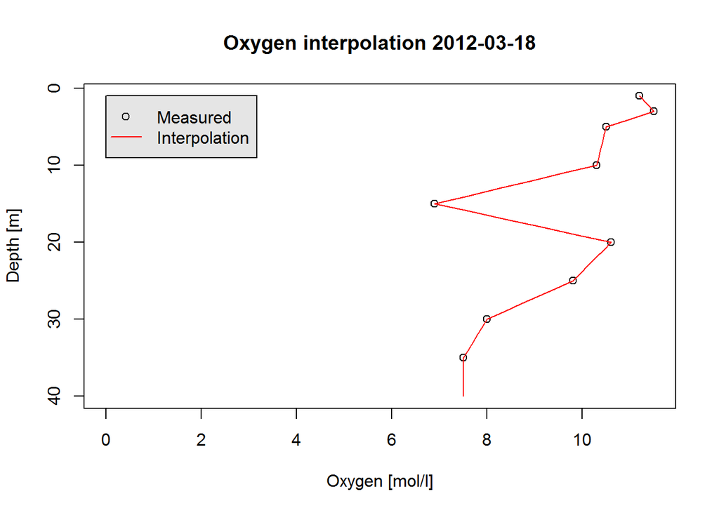

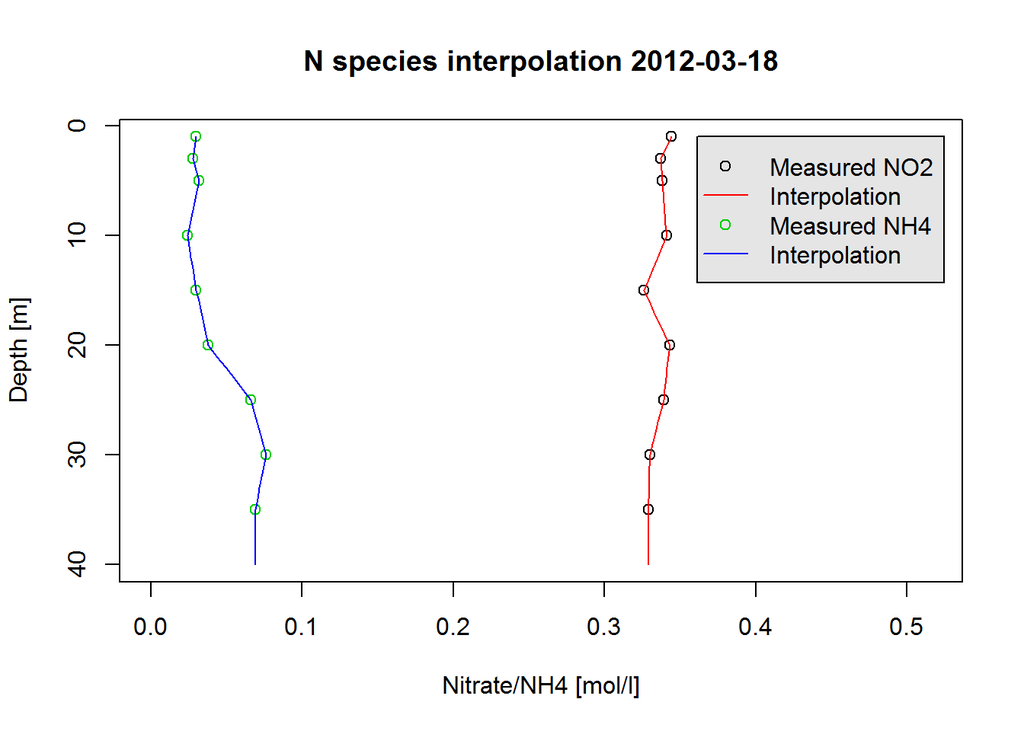

## Depth and Level Corrections

Calculate the appropriate depth for each measurment using available daily level measurments. Use function “realdepth” and use closest day if no level measurment of that day is available. This correction is essential for later calculation of depth to volume and concentration quantification of N species in the lake.

### demonstrate the results according to the new depth scale of randomly selected data

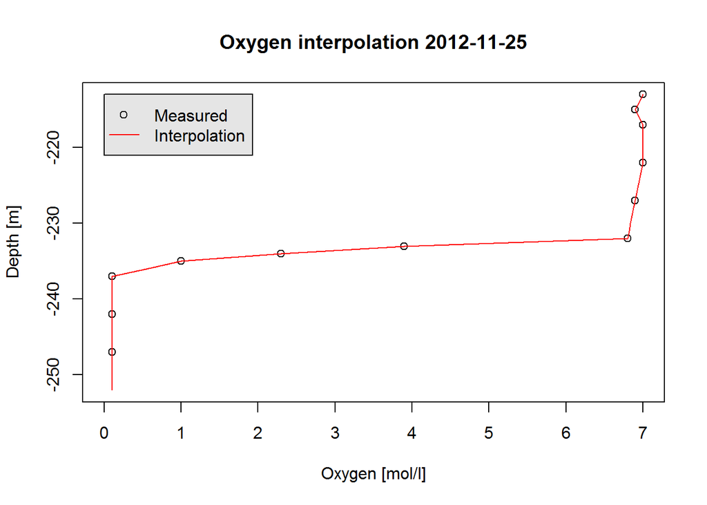

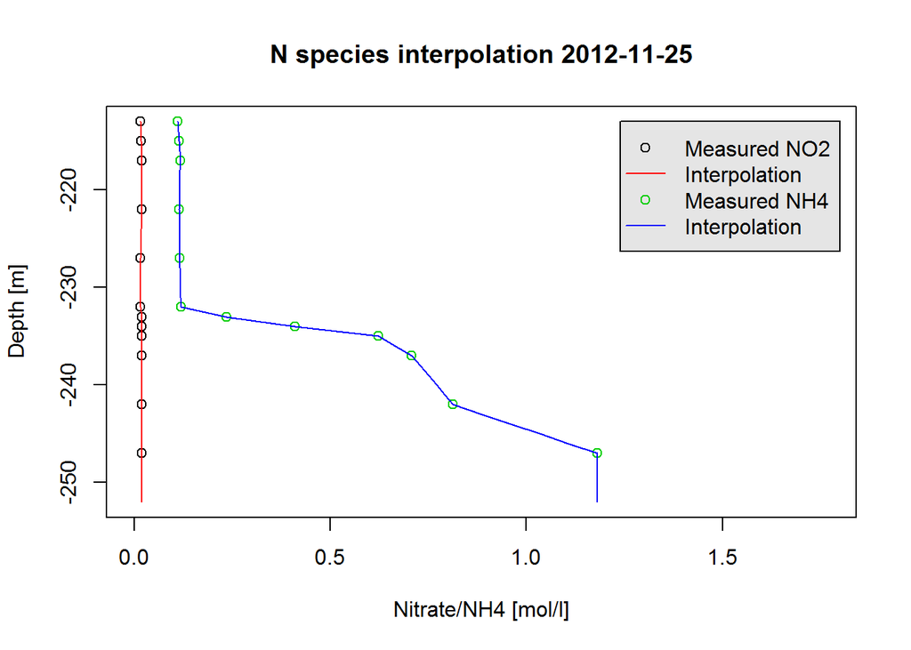

## Quantify the data using lake hypsometric curve

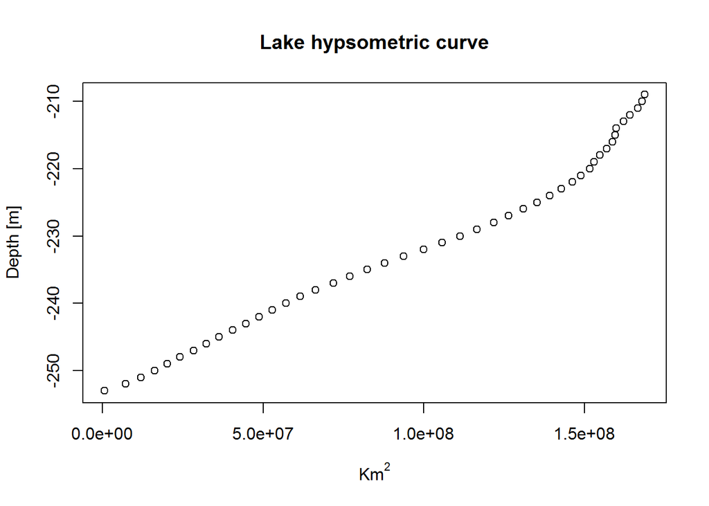

### demonstrate the results according to the new depth scale of randomly selected data

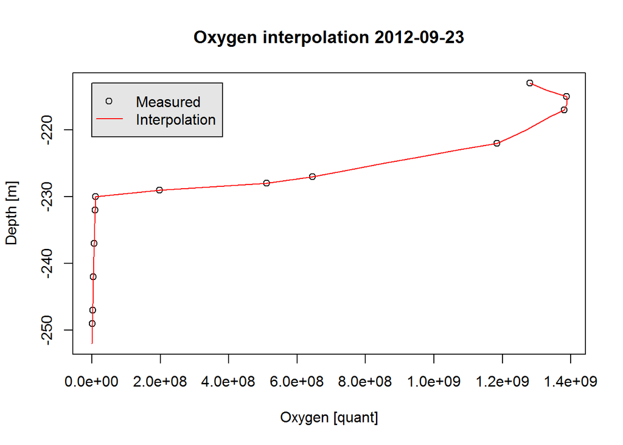

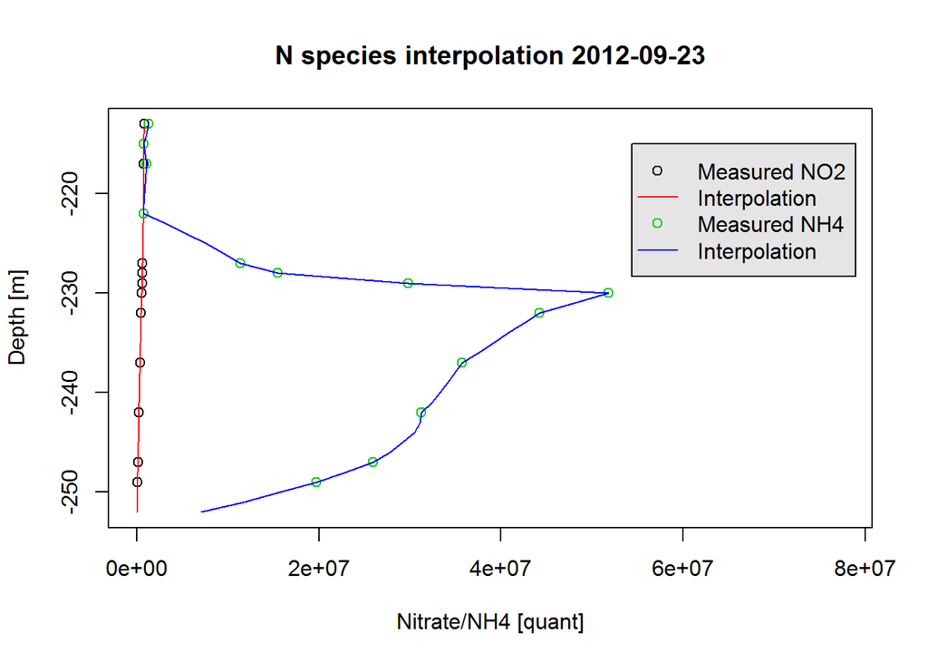

## Time series plots

The following plots provide some visual estimation of the data to visualize time-depth processes for further considerations for the modelling of the processes

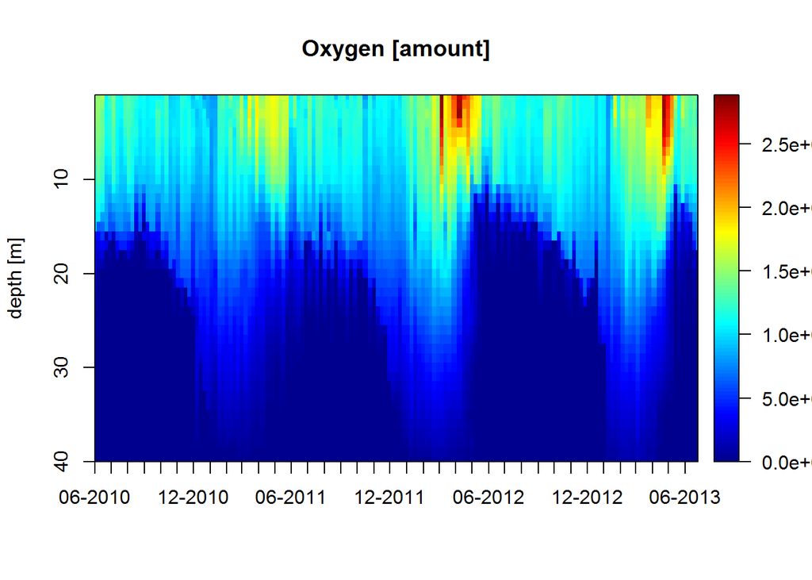

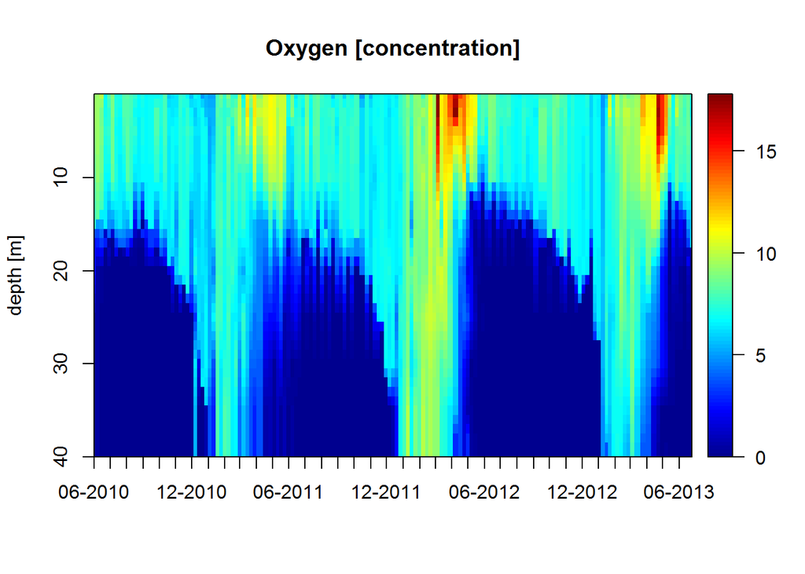

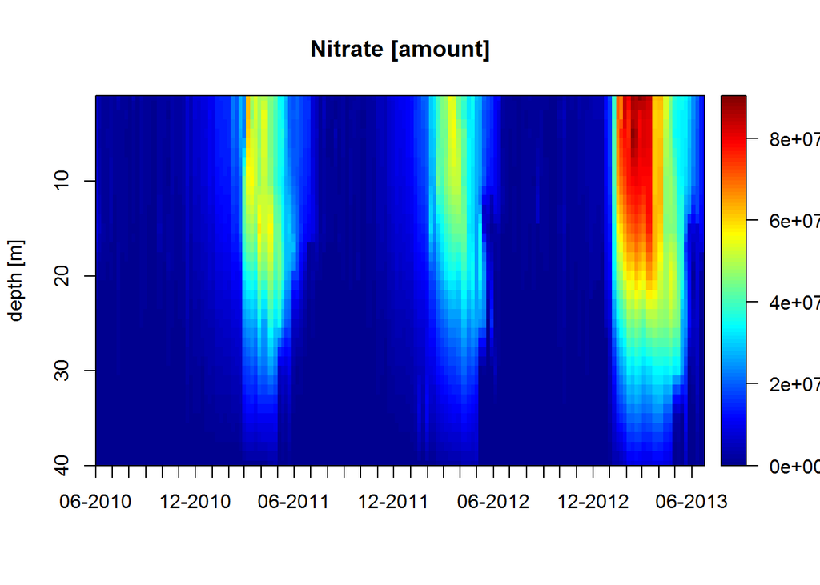

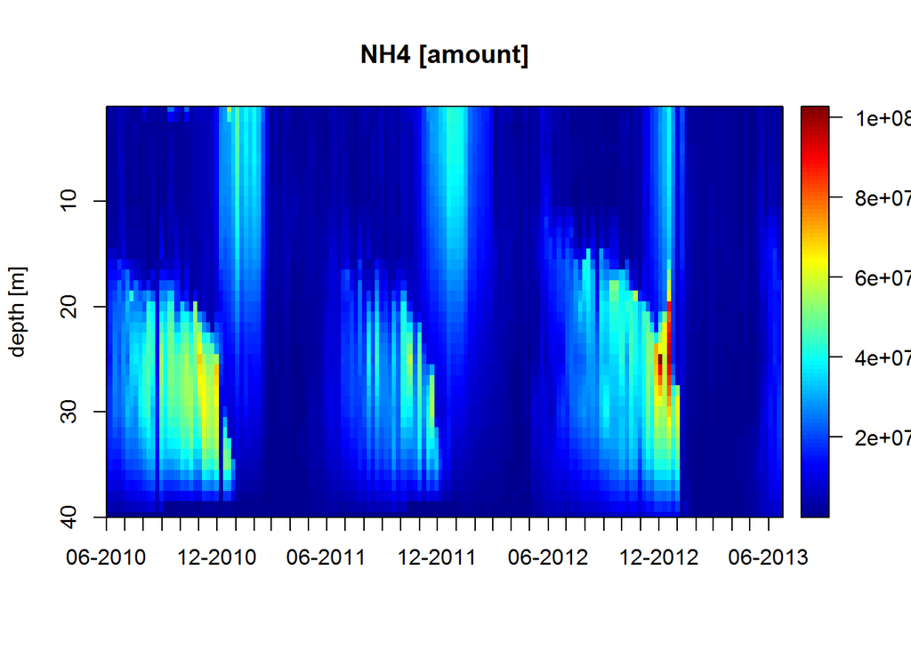

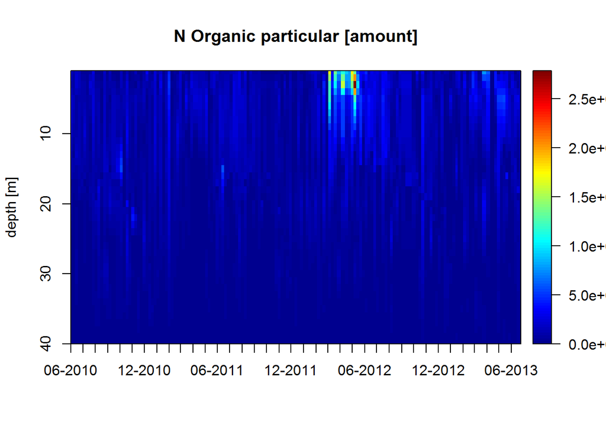

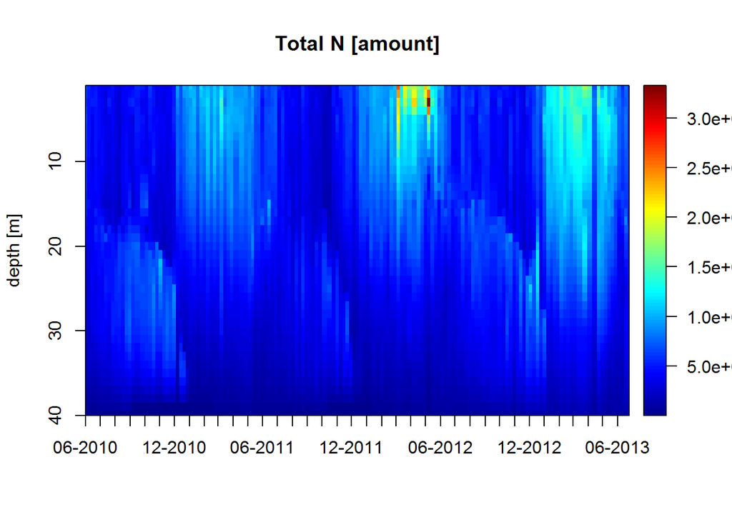

## Time-depth cross sections

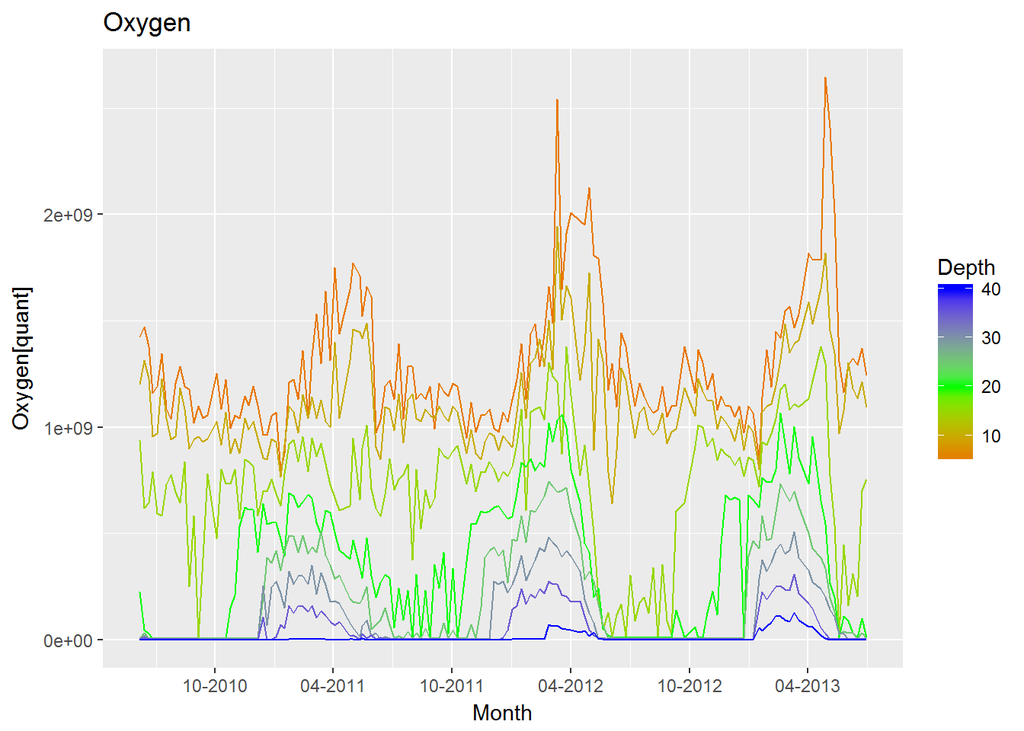

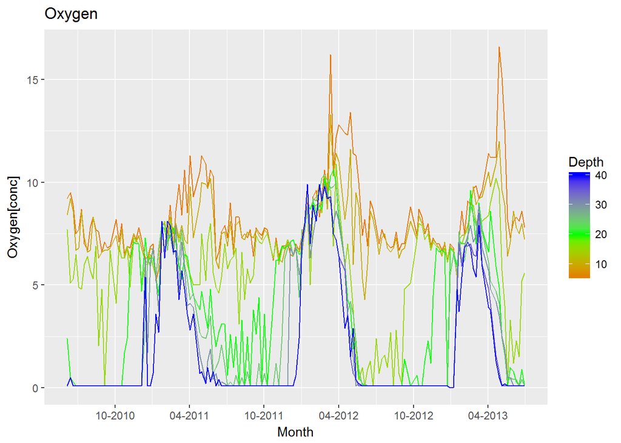

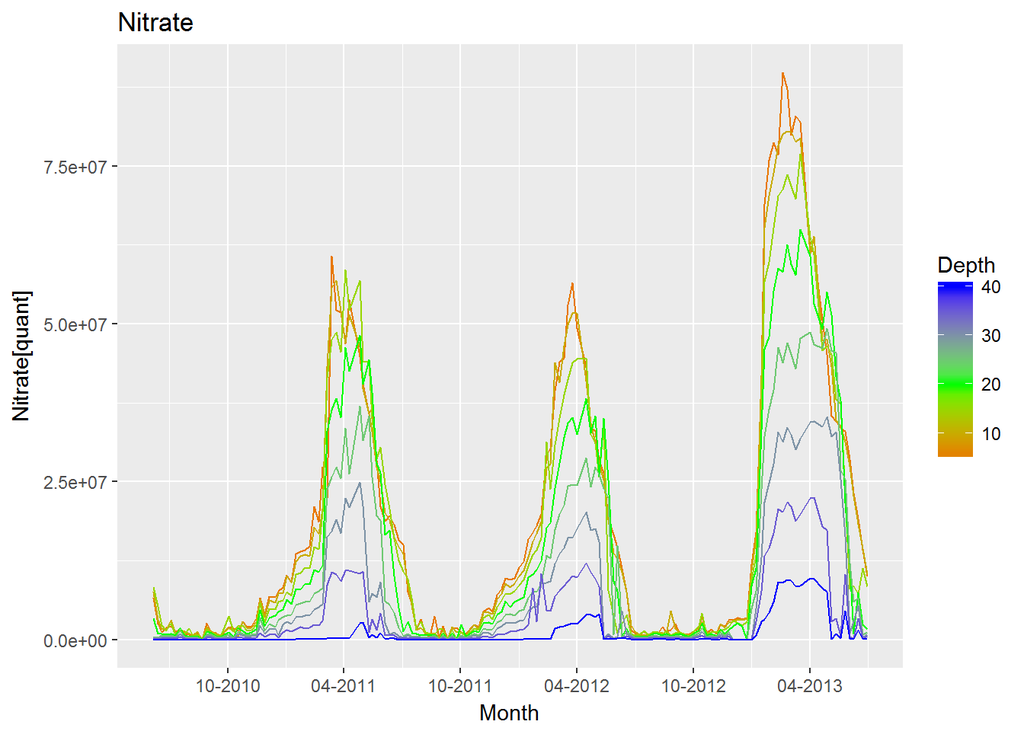

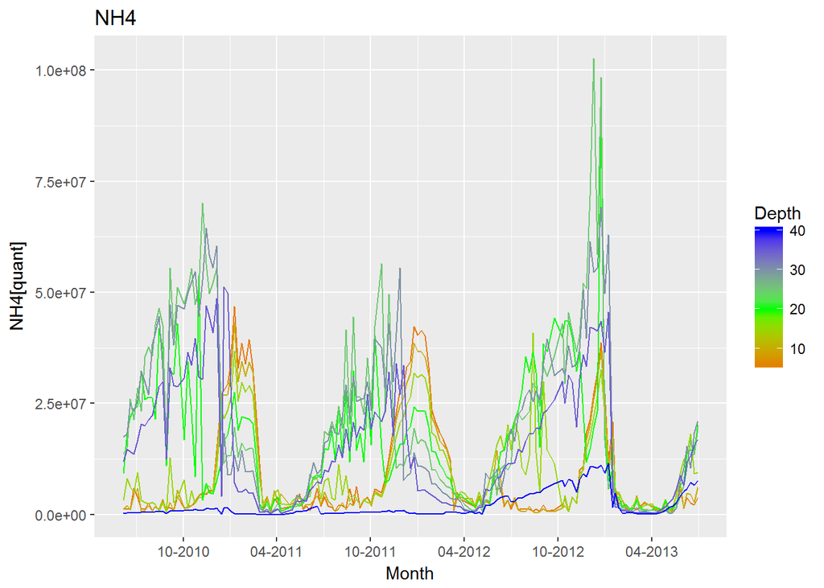

## Correlation plots

The following plots provide some visual estimation of data correlation

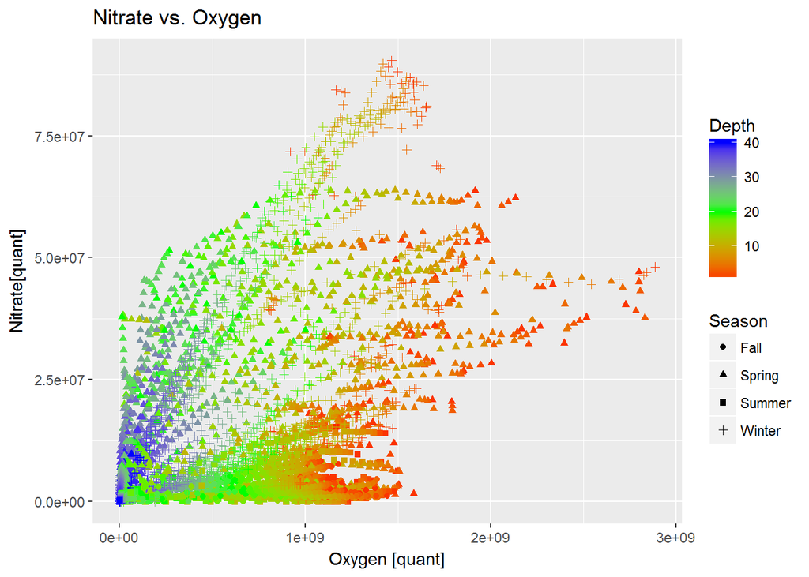

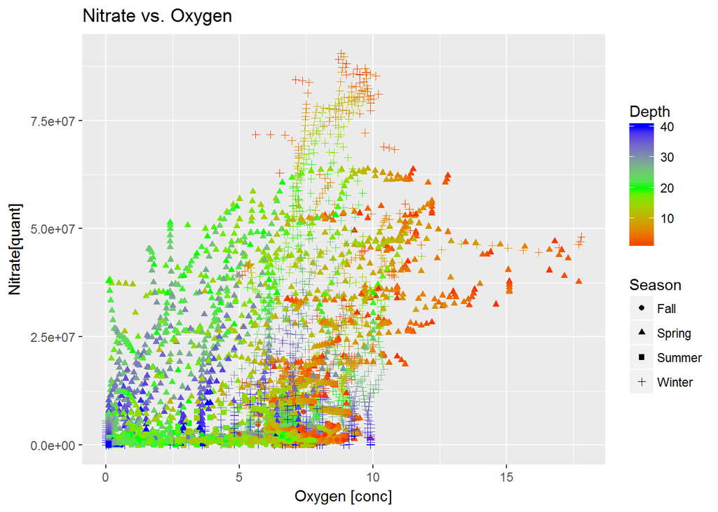

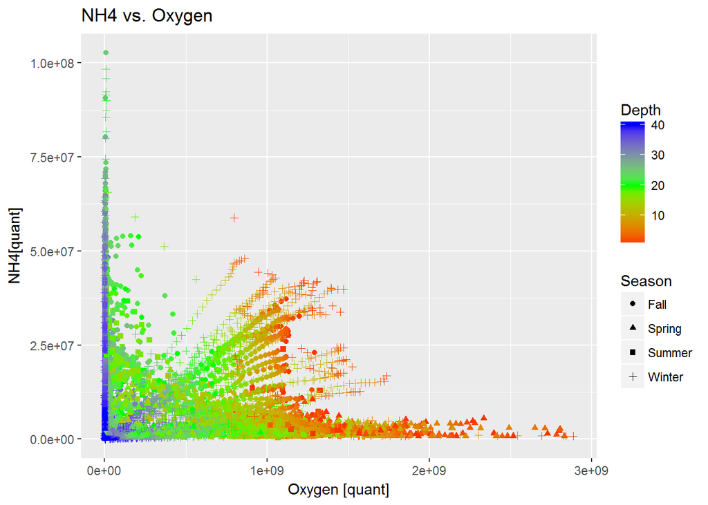

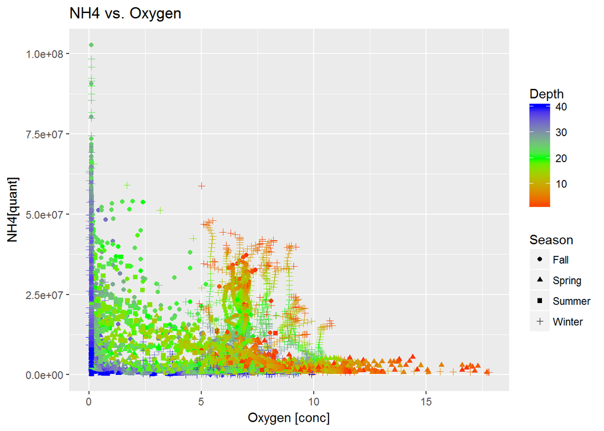

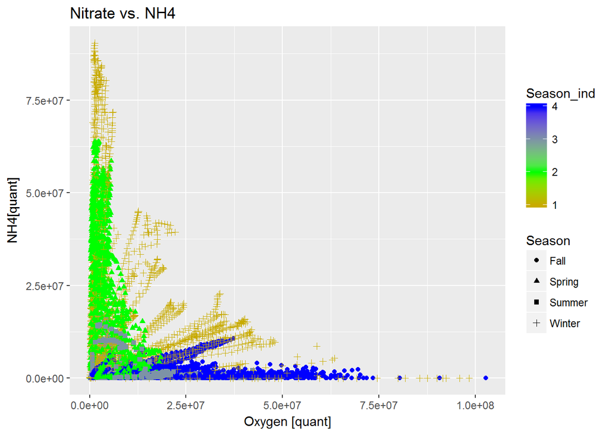

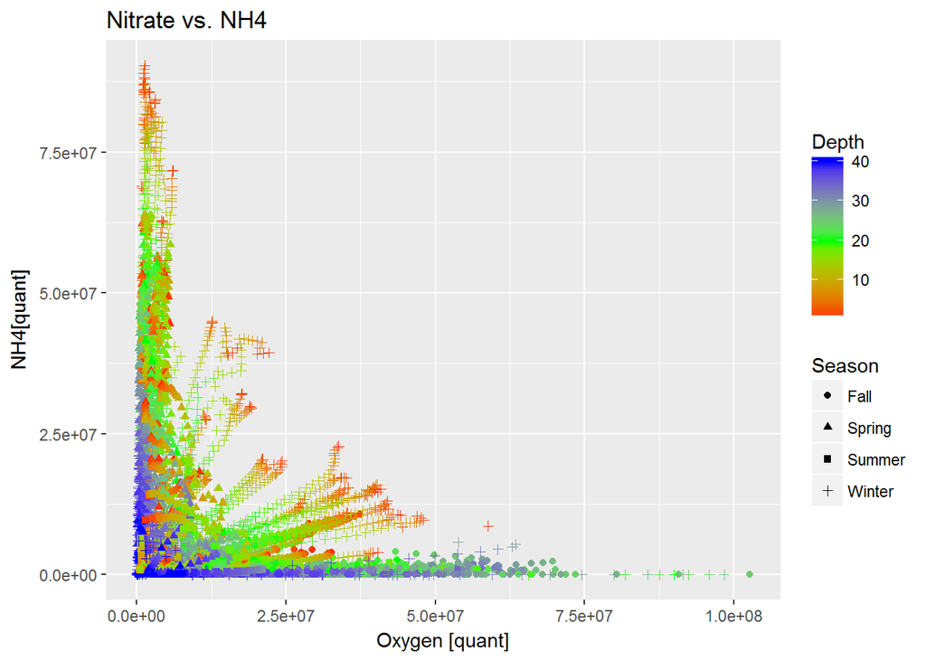

# Model fitting estimation

Nitrification and denitrification are two oposing processes that take place in the present or absence of oxygen. They therefore develop in the upper (nitrification) and lower (denitrification) parts of the lake during episodes of a stratified water column. The model therefore relies on the assumprion that their development depends on the presence of oxygen and the time available for their accumulation. Lake mixing, which takes place during winter, disrupts thier build-up, and uniformly distribute them across the lake, and mixing propagates towards the lake bottom. These two proceeses (stratification and mixing)can be examined in detail in two representative depths of 10m (nitrification) and 30m (denitrification).

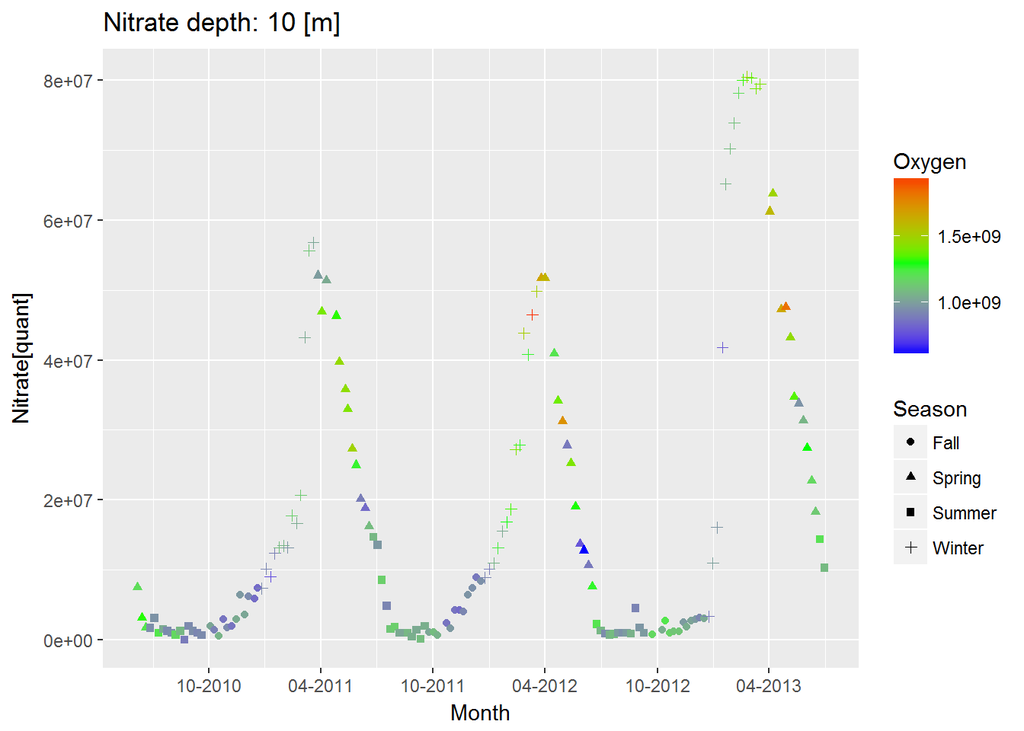

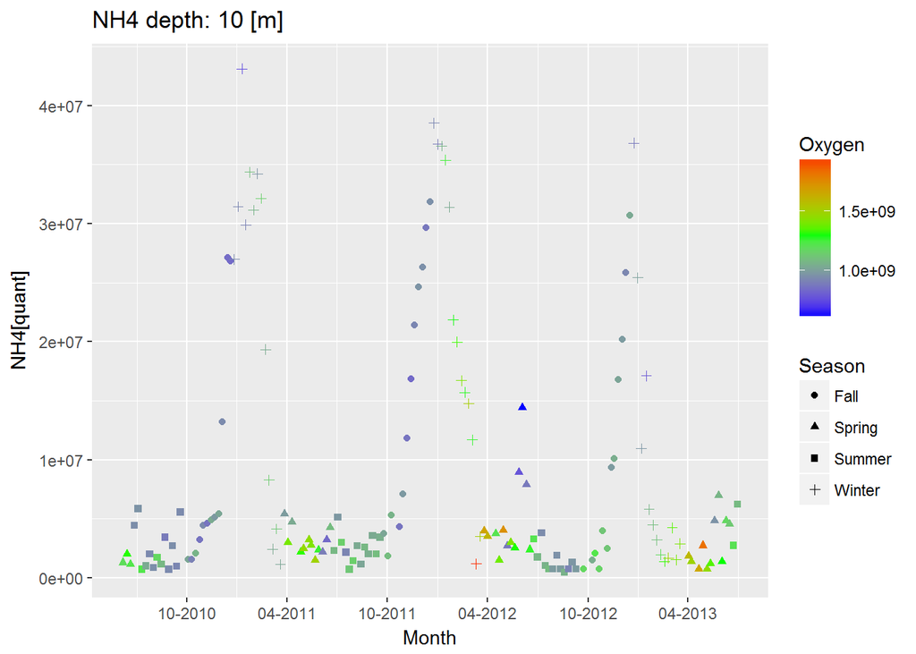

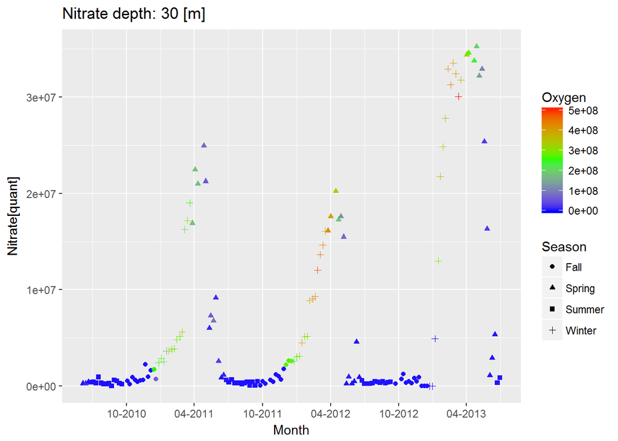

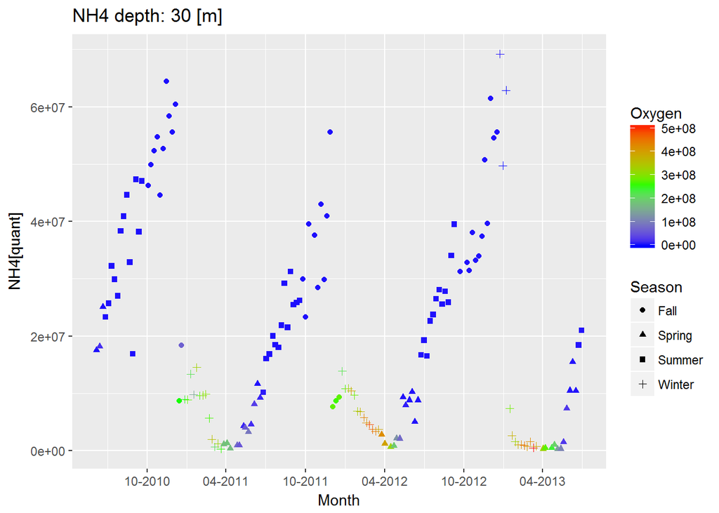

### Process rate estimation

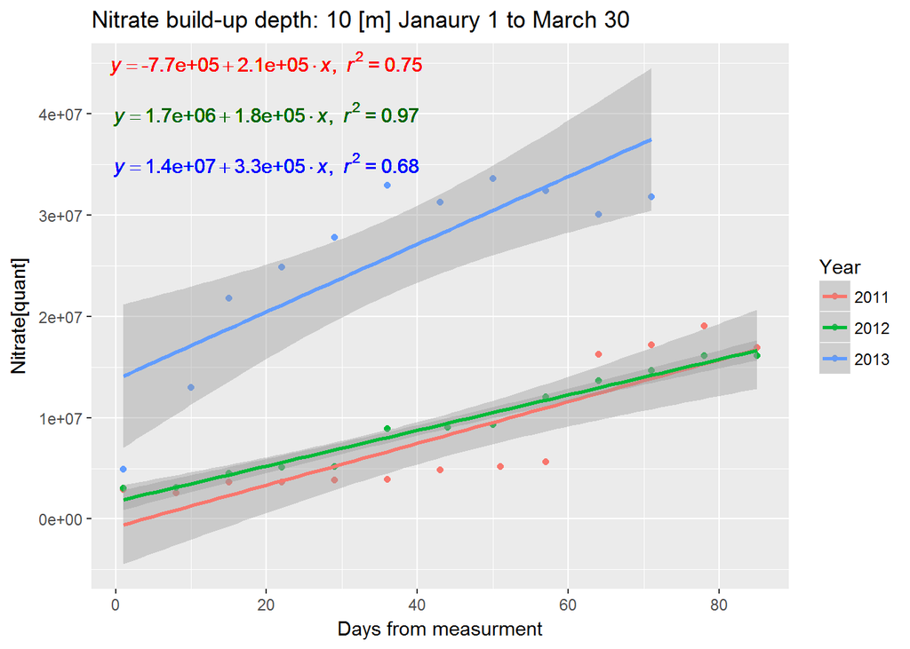

simulate NH4 build-up between April $30^{st}$ and December $1^{st}$ in 30m depth in order to estimate reaction rate

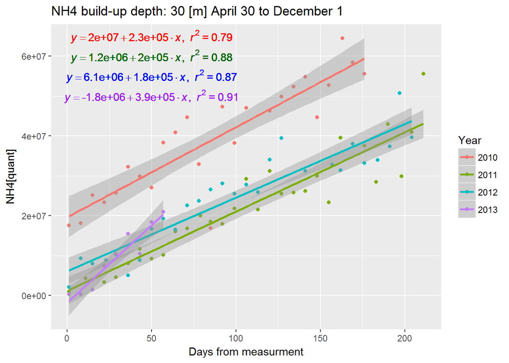

### Coeffiecients assement for all depths

```
##      Depth             a                  b                r2
##  Min.   : 1.00   Min.   :-1163352   Min.   :  2837   Min.   :0.5730
##  1st Qu.:10.75   1st Qu.: -315929   1st Qu.:223195   1st Qu.:0.6953
##  Median :20.50   Median : 2589163   Median :437797   Median :0.7545
##  Mean   :20.50   Mean   : 9884307   Mean   :409771   Mean   :0.7765
##  3rd Qu.:30.25   3rd Qu.:12924573   3rd Qu.:569284   3rd Qu.:0.9409
##  Max.   :40.00   Max.   :44544584   Max.   :822536   Max.   :0.9737
##       Year
##  Min.   :2011
##  1st Qu.:2011
##  Median :2012
##  Mean   :2012
##  3rd Qu.:2013
##  Max.   :2013
```

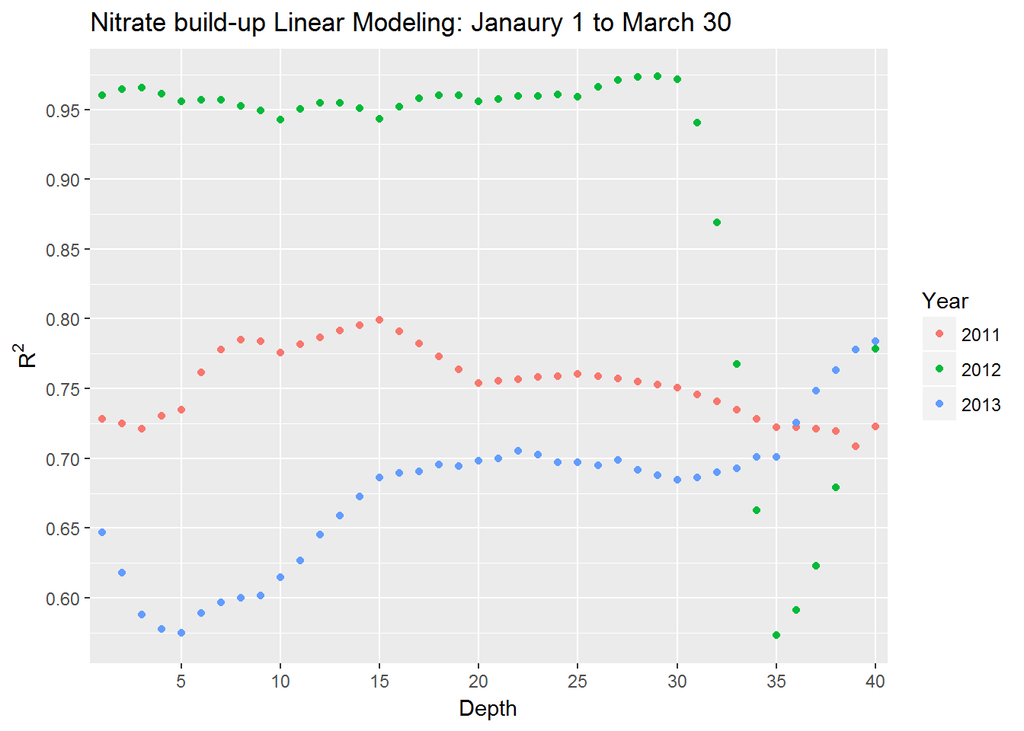

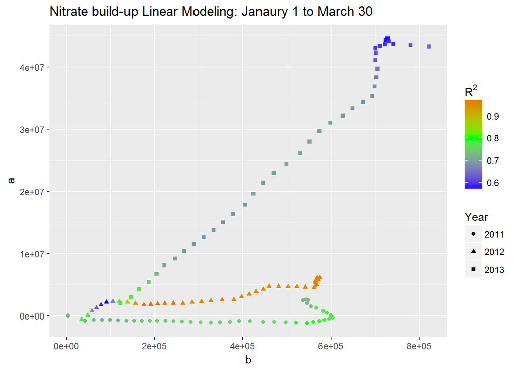

```
##      Depth             a                  b                 r2
##  Min.   : 1.00   Min.   :-2209182   Min.   :-104262   Min.   :0.0003153
##  1st Qu.:10.75   1st Qu.: 1373549   1st Qu.:  21419   1st Qu.:0.2240937
##  Median :20.50   Median : 2140742   Median :  81791   Median :0.4588809
##  Mean   :20.50   Mean   : 4868893   Mean   : 120362   Mean   :0.5247795
##  3rd Qu.:30.25   3rd Qu.: 6149996   3rd Qu.: 200613   3rd Qu.:0.9020609
##  Max.   :40.00   Max.   :27822019   Max.   : 388468   Max.   :0.9818000
##       Year
##  Min.   :2010
##  1st Qu.:2011
##  Median :2012
##  Mean   :2012
##  3rd Qu.:2012
##  Max.   :2013
```

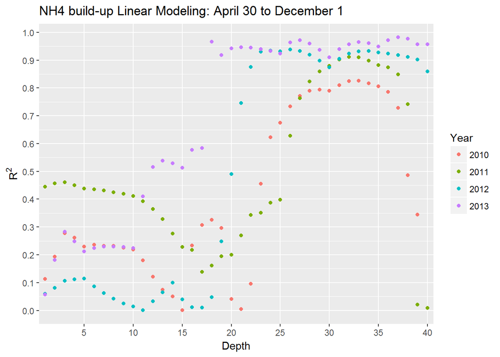

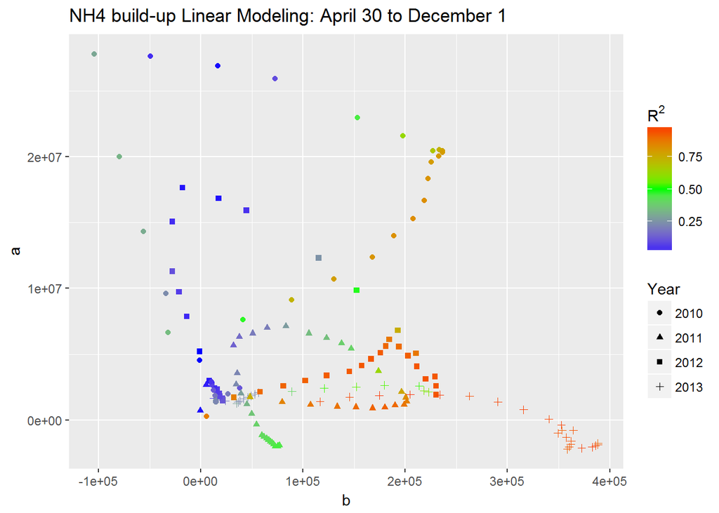